# Part I - Prosper Loan Data

## Introduction

This data set contains information about individuals who have received personal loans from Prosper between 2005 and 2014. This data set contains 113,937 loans with 81 variables on each loan, including loan amount, borrower rate (or interest rate), current loan status, borrower income, and many others.

## Preliminary Wrangling

```python
# import all packages and set plots to be embedded inline
import numpy as np
import pandas as pd
import matplotlib.pyplot as plt
import seaborn as sns

%matplotlib inline

pd.set_option('display.max_colwidth', None) # to display the whole strings and not collapse them
pd.set_option('display.max_columns', None) # to not collapse columns when viewing data
pd.set_option('display.max_rows', None) # to display all rows in the output

import warnings
warnings.filterwarnings("ignore") # warnings off
```

```python
full_loan_df = pd.read_csv('prosperLoanData.csv')
```

```python
print(full_loan_df.shape)
print(full_loan_df.dtypes)
print(full_loan_df.head())
```

```
(113937, 81)
ListingKey                              object
ListingNumber                            int64
ListingCreationDate                     object
CreditGrade                             object
Term                                     int64
LoanStatus                              object
ClosedDate                              object
BorrowerAPR                            float64
BorrowerRate                           float64
LenderYield                            float64
EstimatedEffectiveYield                float64
EstimatedLoss                          float64
EstimatedReturn                        float64
ProsperRating (numeric)                float64
ProsperRating (Alpha)                   object
ProsperScore                           float64
ListingCategory (numeric)                int64
BorrowerState                           object
Occupation                              object
EmploymentStatus                        object
EmploymentStatusDuration               float64
IsBorrowerHomeowner                       bool
CurrentlyInGroup                          bool
GroupKey                                object
DateCreditPulled                        object
CreditScoreRangeLower                  float64
CreditScoreRangeUpper                  float64
FirstRecordedCreditLine                 object
CurrentCreditLines                     float64
OpenCreditLines                        float64
TotalCreditLinespast7years             float64
OpenRevolvingAccounts                    int64
OpenRevolvingMonthlyPayment            float64
InquiriesLast6Months                   float64
TotalInquiries                         float64
CurrentDelinquencies                   float64
AmountDelinquent                       float64
DelinquenciesLast7Years                float64
PublicRecordsLast10Years               float64
```

[output cut: 216 more lines]

```
4                0.0                    0.0                  0.0

   LP_NonPrincipalRecoverypayments  PercentFunded  Recommendations  \
0                              0.0            1.0                0
1                              0.0            1.0                0
2                              0.0            1.0                0
3                              0.0            1.0                0
4                              0.0            1.0                0

   InvestmentFromFriendsCount  InvestmentFromFriendsAmount  Investors
0                           0                          0.0        258
1                           0                          0.0          1
2                           0                          0.0         41
3                           0                          0.0        158
4                           0                          0.0         20
```

### What is/are the main feature(s) of interest in your dataset?

The main features that I am most interested in is which aspects of a borrower's financial health affect the loan they can get.

### What features in the dataset do you think will help support your investigation into your feature(s) of interest?

I think I'll need to focus in on the borrower's financial information. Specifically their income, credit score, employment status, debt-to-income ratio, etc. I'll also need to capture the loan interest rate, term and loan amount.

I'm going to do some initial cleaning of the dataset

```python
# Filter data frame
loan_df = full_loan_df[['ListingNumber',
                        'Term',
                        'BorrowerAPR',
                        'Occupation',
                        'EmploymentStatus',
                        'IsBorrowerHomeowner',
                        'CreditScoreRangeLower',
                        'OpenRevolvingAccounts',
                        'TotalInquiries',
                        'CurrentDelinquencies',
                        'DebtToIncomeRatio',
                        'IncomeRange',
                        'LoanOriginalAmount',
                        'LoanOriginationDate']
                        ]

# Drop duplicate loans in column 'ListingNumber'
loan_df = loan_df.drop_duplicates(subset=['ListingNumber'])

# Drop loans with missing information
loan_df = loan_df.dropna()

# Drop loans with 'Not Displayed' in the 'IncomeRange' column
loan_df = loan_df[~(loan_df['IncomeRange'].str.contains('Not displayed'))]

# Reset index
loan_df.reset_index(drop=True, inplace=True)

# Confirm changes
loan_df.info()
```

```
<class 'pandas.core.frame.DataFrame'>
RangeIndex: 95703 entries, 0 to 95702
Data columns (total 14 columns):
 #   Column                 Non-Null Count  Dtype
---  ------                 --------------  -----
 0   ListingNumber          95703 non-null  int64
 1   Term                   95703 non-null  int64
 2   BorrowerAPR            95703 non-null  float64
 3   Occupation             95703 non-null  object
 4   EmploymentStatus       95703 non-null  object
 5   IsBorrowerHomeowner    95703 non-null  bool
 6   CreditScoreRangeLower  95703 non-null  float64
 7   OpenRevolvingAccounts  95703 non-null  int64
 8   TotalInquiries         95703 non-null  float64
 9   CurrentDelinquencies   95703 non-null  float64
 10  DebtToIncomeRatio      95703 non-null  float64
 11  IncomeRange            95703 non-null  object
 12  LoanOriginalAmount     95703 non-null  int64
 13  LoanOriginationDate    95703 non-null  object
dtypes: bool(1), float64(5), int64(4), object(4)
memory usage: 9.6+ MB
```

```python
# Clean up data types

# Change these columns to int because these values are not decimals
loan_df = loan_df.astype({'CreditScoreRangeLower': int, 'TotalInquiries': int, 'CurrentDelinquencies': int})

# Change 'LoanOriginationDate' to datetime
loan_df['LoanOriginationDate'] = pd.to_datetime(loan_df['LoanOriginationDate'])

print(loan_df.dtypes)
loan_df.head(1)
```

```
ListingNumber                     int64
Term                              int64
BorrowerAPR                     float64
Occupation                       object
EmploymentStatus                 object
IsBorrowerHomeowner                bool
CreditScoreRangeLower             int64
OpenRevolvingAccounts             int64
TotalInquiries                    int64
CurrentDelinquencies              int64
DebtToIncomeRatio               float64
IncomeRange                      object
LoanOriginalAmount                int64
LoanOriginationDate      datetime64[ns]
dtype: object
```

|  | ListingNumber | Term | BorrowerAPR | Occupation | EmploymentStatus | IsBorrowerHomeowner | CreditScoreRangeLower | OpenRevolvingAccounts | TotalInquiries | CurrentDelinquencies | DebtToIncomeRatio | IncomeRange | LoanOriginalAmount | LoanOriginationDate |
| --- | --- | --- | --- | --- | --- | --- | --- | --- | --- | --- | --- | --- | --- | --- |
| 0 | 193129 | 36 | 0.16516 | Other | Self-employed | True | 640 | 1 | 3 | 2 | 0.17 | $25,000-49,999 | 9425 | 2007-09-12 |

```python
# Further cleaning of outliers in LoanOriginalAmount

def remove_outliers_by_group(df, group_col, target_col):
    def iqr_filter(group):
        Q1 = group[target_col].quantile(0.30)
        Q3 = group[target_col].quantile(0.69)
        IQR = Q3 - Q1
        lower = Q1 - 1.5 * IQR
        upper = Q3 + 1.5 * IQR
        return group[(group[target_col] >= lower) & (group[target_col] <= upper)]

    return df.groupby(group_col, group_keys=False).apply(iqr_filter)

loan_df = remove_outliers_by_group(loan_df, 'IncomeRange', 'LoanOriginalAmount')
```

```python
# Saving the cleaned dataset to .csv

loan_df.to_csv('Prosper_Loan_Clean.csv')
```

## Univariate Exploration

In this section, I will start plotting variables together and explore through the data.

```python
# Create my labels function for all graphs

def labels(title, x_label, y_label):
    plt.title(title)
    plt.xlabel(x_label)
    plt.ylabel(y_label)
```

For this first chart, I am going to show the typcial frequency of loans with a specific loan APR. I will graph the APR with the total loans of the dataset.

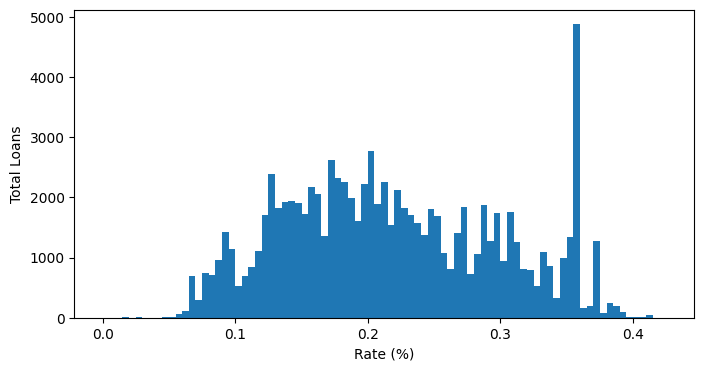

```python
# start with a standard-scaled plot
binsize = .005
bins = np.arange(0, loan_df['BorrowerAPR'].max()+binsize, binsize)

plt.figure(figsize=[8, 4])
plt.hist(data = loan_df, x = 'BorrowerAPR', bins=bins)
labels('', 'Rate (%)', 'Total Loans')
plt.show()
```

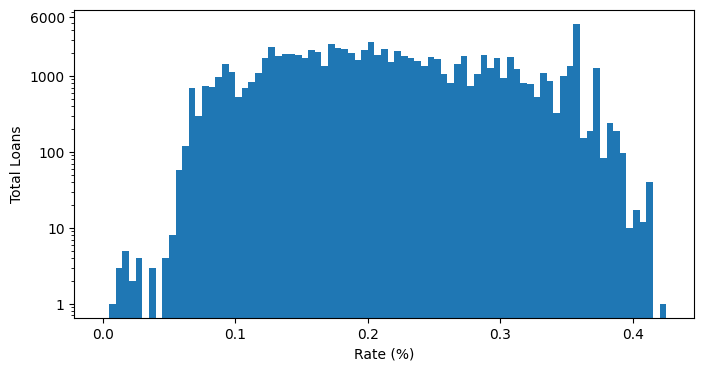

```python
# It looks like there is data between 0.0 and 0.06 and .4+ but it's hard to see due to the y-axis scale. Let's use the log scale factor for the y-axis

binsize = .005
bins = np.arange(0, loan_df['BorrowerAPR'].max()+binsize, binsize)

plt.figure(figsize=[8, 4])
plt.hist(data = loan_df, x = 'BorrowerAPR', bins=bins)
labels('', 'Rate (%)', 'Total Loans')
plt.yscale('log')
plt.yticks([1, 1e1, 1e2, 1e3, 6e3], ['1', '10', '100', '1000', '6000'])
plt.show()
```

As shown with both charts, the majority of the 'BorrowerAPR' rates fall between .06 to .36. This seems like a reasonable distribution of APR rates.

Now I'd like to know what the employment status is of all of the borrowers.

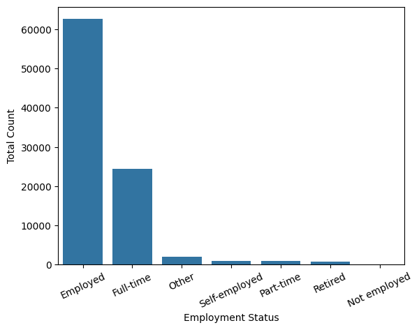

```python
order = loan_df['EmploymentStatus'].value_counts().index

sns.countplot(data = loan_df, x = 'EmploymentStatus', order=order)
plt.xticks(rotation = 25)
labels('', 'Employment Status', 'Total Count')
```

This chart is reasonable as well for a lending company to give the majority of their loans to borrowers who have a job.

Now I'll view the distribution of the borrower's debt to income ratio

```
(0.0, 1.0)
```

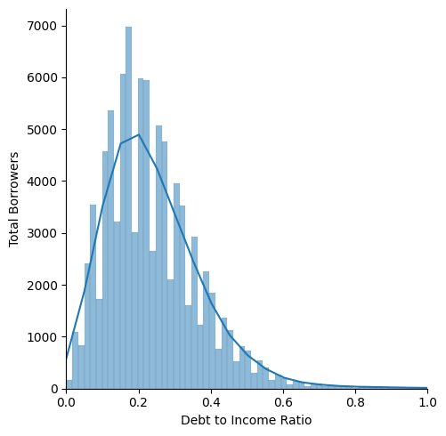

```python
# first lets examine the distribution where 'DebtToIncomeRatio' <= 1

sns.displot(loan_df.DebtToIncomeRatio, kde=True);
labels('','Debt to Income Ratio', 'Total Borrowers')
plt.xlim((0, 1))
```

This chart is reasonable as well, the more debt the borrower has, the less likely they received a loan from Prosper.

Now I'd like to know what are the ranges of income for each of the borrowers.

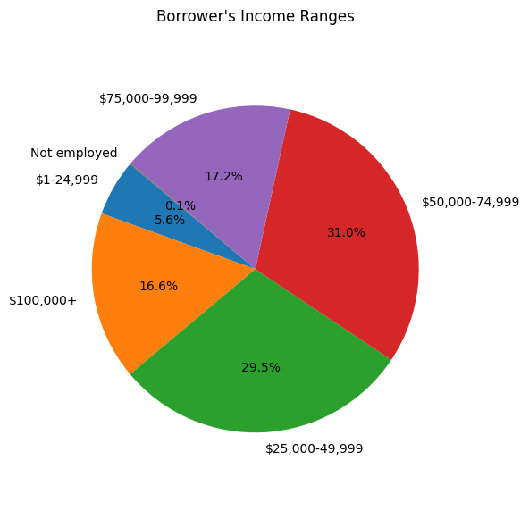

```python
# Count the frequency of 'IncomeRange'
income_range_counts = loan_df['IncomeRange'].value_counts().sort_index()

# Create the pie chart
plt.figure(figsize=(6, 6))
plt.pie(income_range_counts, labels=income_range_counts.index, autopct='%1.1f%%', startangle=140)
labels("Borrower's Income Ranges", '', '')
plt.axis('equal')
plt.tight_layout()
plt.show()
```

The majority of the borrowers have incomes between $25,000 and $75,000.

How many of these borrowers own their own home?

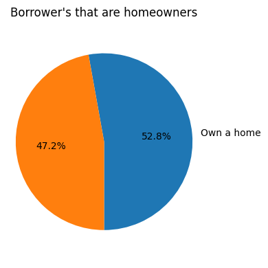

```python
# Count the frequency of 'IncomeRange'
homeowner_counts = loan_df['IsBorrowerHomeowner'].value_counts()

# Create the pie chart
plt.figure(figsize=(4, 4))
plt.pie(homeowner_counts, labels=['Own a home', ""], autopct='%1.1f%%', startangle=270)
homeowner_counts.index#
labels("Borrower's that are homeowners", '', '')
plt.axis('equal')
plt.tight_layout()
plt.show()
```

Now finally I'd like to know distribution of loan amounts that Prosper lent to borrowers.

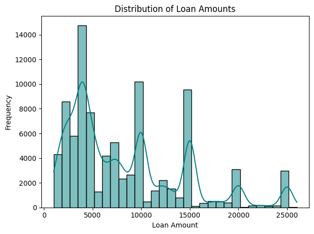

```python
# 'LoanAmount' chart

sns.histplot(loan_df['LoanOriginalAmount'], bins=30, kde=True, color='teal')
labels('Distribution of Loan Amounts', 'Loan Amount', 'Frequency')
plt.tight_layout()
plt.show()
```

A large portion of the loans were $5,000 or less with not very many loans issued over $15,000.

### Discuss the distribution(s) of your variable(s) of interest. Were there any unusual points? Did you need to perform any transformations?

I started with looking at the overall 'BorrowerAPR' in the data. The first graph showed the data but due to the overall quantity, it was hard to determine how many loans there were with the APRs between 0.0 and 0.06 and .4+. I changed the y-axis from a linear scale to a logarithmic scale so we can see that data.

### Of the features you investigated, were there any unusual distributions? Did you perform any operations on the data to tidy, adjust, or change the form of the data? If so, why did you do this?

For the 'EmploymentStatus' variable, it wasn't the best set of data that I thought there was originally. I actually question the data and if it is actually accurate based on the borrower's responses. I'm not sure what the question was during the loan application process but one person could have chosen 'employed' as their response but they were full-time as well. I don't think I plan to use the variable 'EmploymentStatus' because of the potential inaccuracy.

For the Borrower's Income Range pie chart, when I first charted it, there was a "Not Displayed" value for a few loans that I didn't catch during the initial cleaning. I saw it on the first iteration of the pie chart so I had to go back to my cleaning stage, remove all loans with the "Not Displayed" value and re-chart the graph.

## Bivariate Exploration

Now that I have some understanding of some general relationships of this dataset, I'm going to start digging into more speicifc data in regards to my original interest of how much of a borrowers financial health affects their loan details.

My first comparison I want to look at is a borrower's DTI to loan amount.

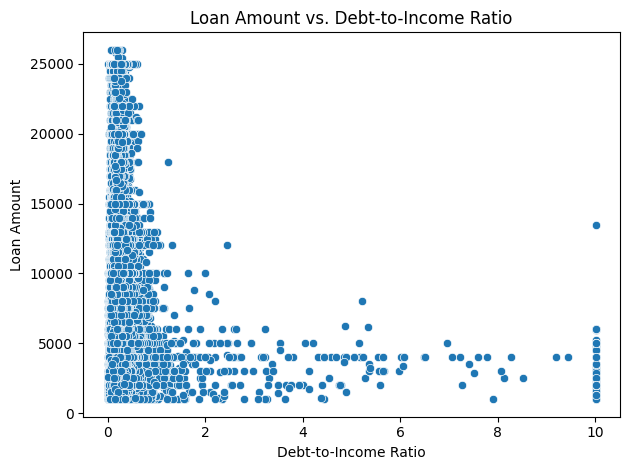

```python
# Create a scatterplot of the 'DebtToIncomeRatio' vs 'LoanOriginalAmount'

sns.scatterplot(data=loan_df, x='DebtToIncomeRatio', y='LoanOriginalAmount')
labels('Loan Amount vs. Debt-to-Income Ratio', 'Debt-to-Income Ratio', 'Loan Amount')
plt.tight_layout()
plt.show()
```

Here we see the general trend is that the vast majority of loans are issued to people with debt ratios less than 2 which seems reasonable. DTI ratios of 10 seem to be an error in the data that would need to be investigated further with the author or company that this data came from.

Now we'll look at the income ranges of the borrowers with how much total loan amount they received.

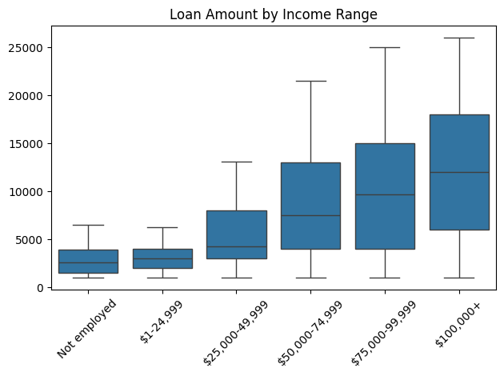

```python
# LoanOriginalAmount vs IncomeRange

income_order = [
    'Not employed',
    '$1-24,999',
    '$25,000-49,999',
    '$50,000-74,999',
    '$75,000-99,999',
    '$100,000+'
    ]

sns.boxplot(data=loan_df, x='IncomeRange', y='LoanOriginalAmount', order=income_order)
plt.xticks(rotation=45)
labels('Loan Amount by Income Range', '','')
plt.tight_layout()
plt.show()
```

Here we see that as the borrower's income increases, the total loan amount increases as well. The averages of each loan amount directly correlates with the increase in income.

While we're still looking at income ranges, let's see if there is any correlation with the interest rate of the loan.

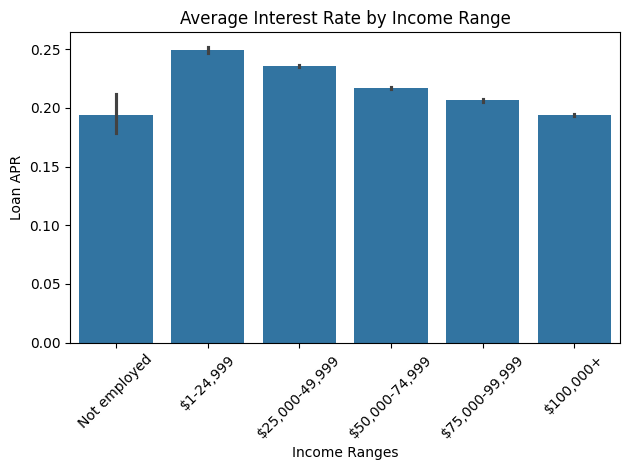

```python
# LoanAPR vs IncomeRange

income_filtered = loan_df[loan_df['IncomeRange'] != 'Not displayed']

sns.barplot(data=income_filtered, x='IncomeRange', y='BorrowerAPR', order=income_order)
plt.xticks(rotation=45)
labels('Average Interest Rate by Income Range', 'Income Ranges', 'Loan APR')
plt.tight_layout()
plt.show()
```

Here we see that as the income increases, the interest rate decreases. Now the 'Not Employed' bar doesn't match the trajectory of the rest of the data. There should be some more investigation of why that is the case. I don't understanding why or how Prosper is able to lend money to individuals who are not employed.

Finally for the last bivariate graph, I want to see if there is a relationship between the APR and the total loan amount.

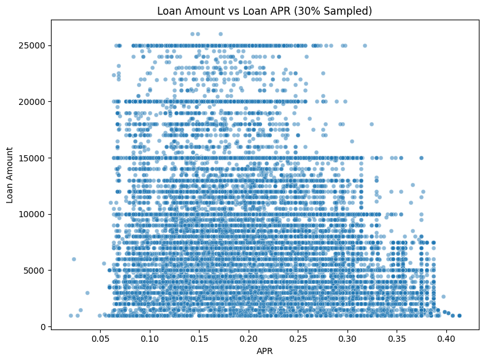

```python
# Create a scatterplot of LoanOriginalAmount vs BorrowerAPR

# Too much data, need to take a sample size
loan_df_sampled = loan_df.sample(frac=.3, random_state=1)

plt.figure(figsize=(8, 6))
sns.scatterplot(
    data=loan_df_sampled,
    x='BorrowerAPR',
    y='LoanOriginalAmount',
    alpha=0.5,
    s=25
)
labels('Loan Amount vs Loan APR (30% Sampled)', 'APR', 'Loan Amount')
plt.tight_layout()
plt.show()
```

### Talk about some of the relationships you observed in this part of the investigation. How did the feature(s) of interest vary with other features in the dataset?

In the Debt-to-Income vs loan amount scatterplot shows a lot of loans issued in the Debt-To-Income ratio of 10. That seems highly unsual for a lender to loan money to a borrower with such a high DTI. Additional questions would need to be asked with the author of this data to confirm if these values are accurate or not.

## Multivariate Exploration

> Create plots of three or more variables to investigate your data even further. Make sure that your investigations are justified, and follow from your work in the previous sections.

The first multivariate chart shows the relationship between the borrower's DTI ratio, if the borrower is a homeowner or not versus the overall loan amount. Due to the volume of loans in the data, I've taken a sampling size of 50%

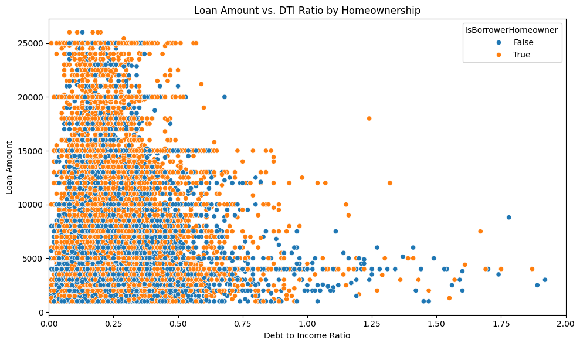

```python
# Scatterplot of DTI, loan amount and homeowner

loan_df_sampled = loan_df.sample(frac=.5, random_state=1)

plt.figure(figsize=(10, 6))
sns.scatterplot(data=loan_df_sampled, x='DebtToIncomeRatio', y='LoanOriginalAmount', hue='IsBorrowerHomeowner')
labels('Loan Amount vs. DTI Ratio by Homeownership', 'Debt to Income Ratio', 'Loan Amount')
plt.xlim(0, 2)
plt.tight_layout()
plt.show()
```

In this graph, it appears that the larger the loan amount, the lender is more likely to issue that loan to borrowers who own a house, especially in the $17,500 and higher loan amounts. The DTI difference is inconclusive.

This next graph is a heatmap of the correlations of specific numeric columns in the 'loan_df'. This will help us see specifically which variables correlate the most.

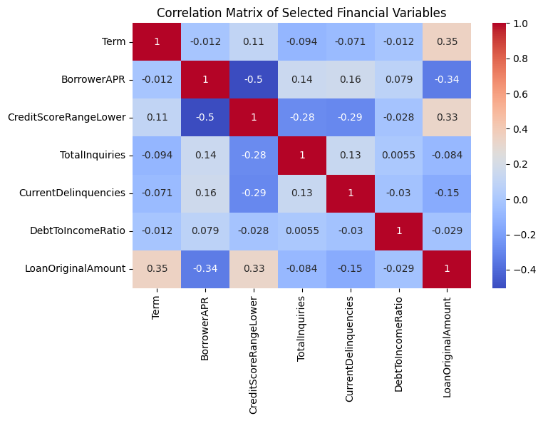

```python
# Correlation matrix heatmap of specific numeric values of the DF

num_cols = ['Term',
           'BorrowerAPR',
           'CreditScoreRangeLower',
           'TotalInquiries',
           'CurrentDelinquencies',
           'DebtToIncomeRatio',
           'LoanOriginalAmount'
           ]

corr_matrix = loan_df[num_cols].corr()

plt.figure(figsize=(8, 6))
sns.heatmap(corr_matrix, annot=True, cmap='coolwarm', xticklabels=num_cols, yticklabels=num_cols)
plt.title('Correlation Matrix of Selected Financial Variables')
plt.tight_layout()
plt.show()
```

This next chart is a scatterplot of the DTI, Loan Amounts and Loan APRs

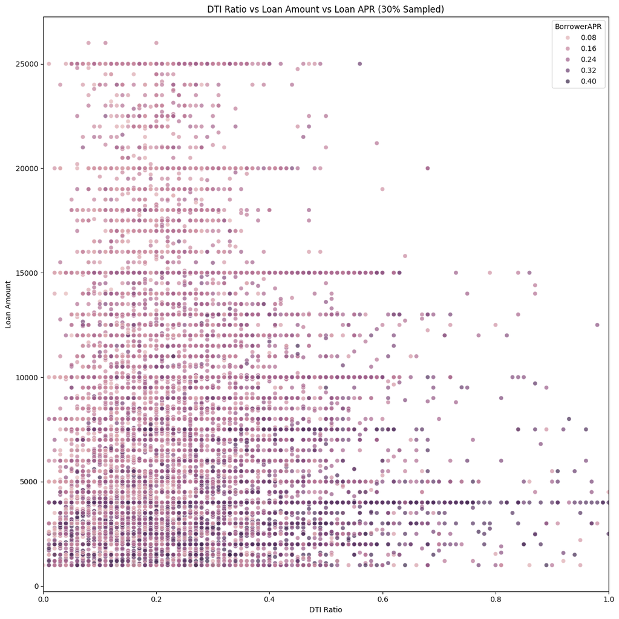

```python
# Scatterplot of DTI, Loan Amount and Loan APR

loan_df_sampled = loan_df.sample(frac=.3, random_state=1)

plt.figure(figsize=(12, 12))
sns.scatterplot(data=loan_df_sampled,
                x='DebtToIncomeRatio',
                y='LoanOriginalAmount',
                hue='BorrowerAPR',
                alpha=0.7
                )
labels('DTI Ratio vs Loan Amount vs Loan APR (30% Sampled)', 'DTI Ratio', 'Loan Amount')
plt.xlim((0, 1))
plt.tight_layout()
plt.show()
```

Here you can clearly see that the lender typically loans money to borrower's at a higher APR when the loan amount is smaller. If the borrow is trying to get a larger loan, the APR is typcally smaller.

This next chart illustrates the loan APR by income range and homeownership

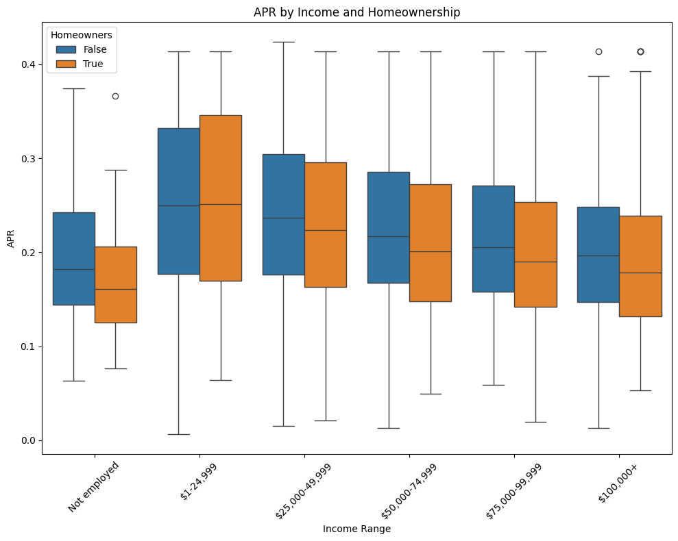

```python
# Box plot of Income Range, APR and Homeowner

plt.figure(figsize=(10,8))
ax = sns.boxplot(data=loan_df,
                 x='IncomeRange',
                 y='BorrowerAPR',
                 hue='IsBorrowerHomeowner',
                 order=income_order
                 )
plt.xticks(rotation=45)
labels('APR by Income and Homeownership', 'Income Range', 'APR')
ax.legend(title='Homeowners')
plt.tight_layout()
plt.show()
```

The chart shows that there is a small decrease in the loan's APR when the borrower owns their own home. It appears that this lender is likely to loan money at a better rate to borrowers who own their own home.

This last chart is a faceted scatterplot showing the comparison between DTI and Loan Amount faceted by Homeownership and colored by Income.

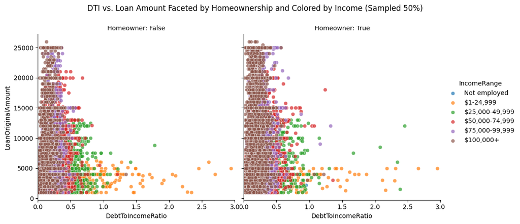

```python
loan_df_sampled = loan_df.sample(frac=.5, random_state=1)

ax = sns.FacetGrid(loan_df_sampled, col="IsBorrowerHomeowner", hue="IncomeRange", hue_order=income_order, height=5)
ax.map(sns.scatterplot, "DebtToIncomeRatio", "LoanOriginalAmount", alpha=0.7)
ax.add_legend()
ax.set_titles("Homeowner: {col_name}")
ax.figure.subplots_adjust(top=0.85)
ax.figure.suptitle('DTI vs. Loan Amount Faceted by Homeownership and Colored by Income (Sampled 50%)')
plt.xlim(0,3)
plt.show()
```

### Talk about some of the relationships you observed in this part of the investigation. Were there features that strengthened each other in terms of looking at your feature(s) of interest?

Using the correlation matrix chart, the borrower's credit score was moderately inversely correlated to the loan APR. This is evidence that helps support my interest in this data set.

Another relationship is the smaller the loan amount the higher the APR.

### Were there any interesting or surprising interactions between features?

One of the relationships that was interesting to me is homeownership and loan amount. In general, when comparing against other borrowers with similar income ranges, Prosper will lend more money to borrowers who own their own homes than those who don't.

## Conclusions

Before exploring through this data set, I had a good idea that the borrower's credit score was going to correlate in some way with the details of the loan that they received. This is a common way lenders decide who they are going to give loans to. One thing I didn't consider was how much owning a home has an affect on the loan amount and APR.

There are some variables that I thought would correlate but don't appear to at all. One set of those was the total credit inquiries compared with the APR or loan amount.